# Hypothesis testing: Toxicity assessment of the MON810 maize

## Introduction

The data set `MON810.csv` consists of several measurements made during a subchronic toxicity study concerning the MON810 maize.

```r
MON810 <- readr::read_csv("data/MON810.csv", show_col_types = FALSE)
rmarkdown::paged_table(MON810)
```

| id | regimen | sex | period | ALBUMIN | ALKPHOSPH | SGPTALT | SGOTAST | BUN | CALCIUM blood | CREAT blood | Glycemia | PHOSPH blood | TOTPROT | SODIUM Sang | POTASSIUM Sang | CHLORIDE Sang | GLOBULINE | AGRATIO | GRAVITY | PH | WBC | RBC | HGB | HCT | MCV | MCH | MCHC | PLT | ABSNEUT | … |
| --- | --- | --- | --- | --- | --- | --- | --- | --- | --- | --- | --- | --- | --- | --- | --- | --- | --- | --- | --- | --- | --- | --- | --- | --- | --- | --- | --- | --- | --- | --- |
| 1 | MON810 | F | 2 | NA | NA | NA | NA | NA | NA | NA | NA | NA | NA | NA | NA | NA | NA | NA | NA | NA | NA | NA | NA | NA | NA | NA | NA | NA | NA | … |
| 2 | MON810 | F | 1 | 4.50 | 73 | 25 | 78 | 14.7 | 9.5 | 0.4 | 107 | 5.6 | 6.2 | 144.00 | 4.2 | 99 | 1.7 | 2.65 | 1.025 | 7.0 | 5.52 | 7.73 | 14.2 | 41.3 | 53.5 | 18.4 | 34.4 | 883 | 0.83 | … |
| 2 | MON810 | F | 2 | 5.30 | 45 | 34 | 75 | 20.8 | 11.9 | 0.6 | 207 | 12.8 | 7.6 | 150.00 | 8.7 | 109 | 2.3 | 2.30 | 1.031 | 7.0 | 7.45 | 8.38 | 15.2 | 44.8 | 53.5 | 18.2 | 33.9 | 790 | 0.86 | … |
| 3 | MON810 | F | 1 | 4.70 | 62 | 37 | 89 | 16.7 | 10.4 | 0.4 | 89 | 7.4 | 6.8 | 145.00 | 4.8 | 97 | 2.1 | 2.24 | 1.041 | 6.0 | 10.00 | 7.97 | 15.5 | 45.2 | 56.6 | 19.4 | 34.3 | 965 | 0.61 | … |
| 3 | MON810 | F | 2 | 5.20 | 31 | 55 | 79 | 17.8 | 11.7 | 0.5 | 157 | 9.9 | 7.5 | 154.00 | 6.1 | 112 | 2.3 | 2.26 | 1.040 | 6.5 | 6.20 | 7.72 | 15.0 | 44.6 | 57.8 | 19.4 | 33.6 | 1070 | 0.75 | … |
| 4 | MON810 | F | 2 | NA | NA | NA | NA | NA | NA | NA | NA | NA | NA | NA | NA | NA | NA | NA | NA | NA | NA | NA | NA | NA | NA | NA | NA | NA | NA | … |
| 5 | MON810 | F | 1 | 4.90 | 77 | 40 | 122 | 18.0 | 10.0 | 0.4 | 108 | 6.1 | 6.5 | 144.00 | 4.5 | 100 | 1.6 | 3.06 | 1.060 | 6.0 | 8.76 | 7.67 | 14.5 | 42.2 | 55.0 | 19.0 | 34.5 | 1132 | 0.74 | … |
| 5 | MON810 | F | 2 | 5.80 | 47 | 33 | 74 | 20.3 | 12.5 | 0.5 | 180 | 11.6 | 7.9 | 151.00 | 7.2 | 110 | 2.1 | 2.76 | 1.066 | 6.5 | 6.62 | 7.88 | 14.9 | 44.7 | 56.7 | 18.9 | 33.4 | 990 | 0.55 | … |
| 6 | MON810 | F | 2 | NA | NA | NA | NA | NA | NA | NA | NA | NA | NA | NA | NA | NA | NA | NA | NA | NA | NA | NA | NA | NA | NA | NA | NA | NA | NA | … |
| 7 | MON810 | F | 2 | NA | NA | NA | NA | NA | NA | NA | NA | NA | NA | NA | NA | NA | NA | NA | NA | NA | NA | NA | NA | NA | NA | NA | NA | NA | NA | … |

[output cut: 590 more lines]

Biochemical parameters reflecting most physiological functions were measured two times (week 5 and 14), in particular through serum and urine chemistry, and hematology. Organ weights were measured at week 14.

The main objective of this study is to evaluate possible GMO effects on these parameters.

## Single comparison

We consider the variable “CALCIUM”.

1. Test if the mean level of calcium for period 2 is the same for males and females (*hint:* plot first the data and justify the test(s) to use).

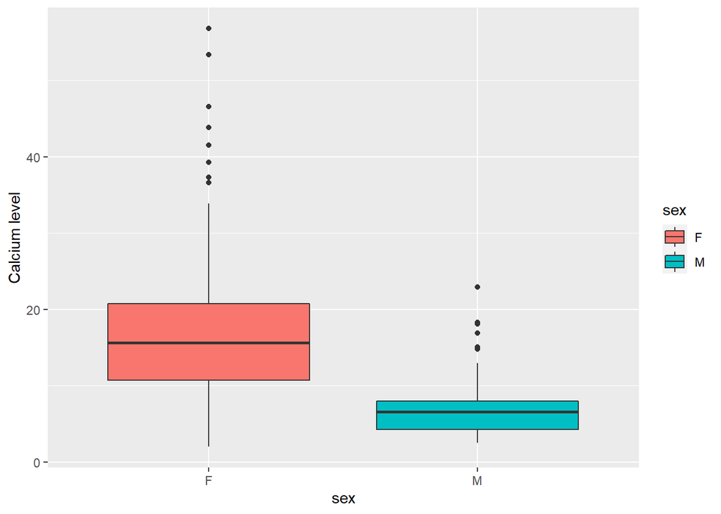

```r
( MON810%>% filter(period == 2))%>%ggplot() + aes(x = sex, y = CALCIUM) + geom_boxplot(aes(fill = sex)) + ylab("Calcium level")
```

Looking at the two box plots, it seems that the means of the two populations are different. Let’s discuss if we can apply a student test to see that.

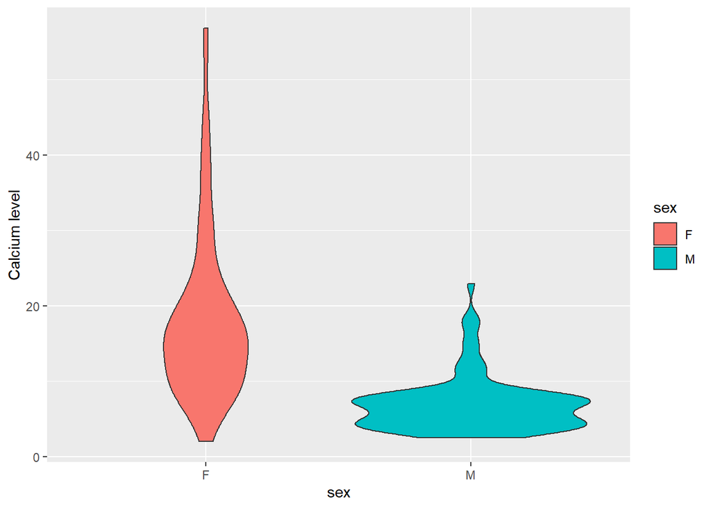

```r
(MON810 %>% filter(period == "2")) %>% ggplot() + aes(x = sex, y = CALCIUM) + geom_violin(aes(fill = sex)) + ylab("Calcium level")
```

We see that the two distibutions are skewed and are not symmetric so a student test can’t be applied here. We apply a wilcoxon test.

```r
male_period2 = ( MON810%>% filter(period == 2 & sex =="M")) $"CALCIUM"
female_period2 =  (MON810%>% filter(period == 2 & sex =="F")) $"CALCIUM"

wilcox.test(male_period2,female_period2,alternative = "two.sided")
```

```
##
##  Wilcoxon rank sum test with continuity correction
##
## data:  male_period2 and female_period2
## W = 977, p-value < 2.2e-16
## alternative hypothesis: true location shift is not equal to 0
```

The p-value is $2.2 \times 10^{-16} < 0.05$. We reject the nuull hypothesis that the two mean levels are equal.

```r
wilcox.test(male_period2,female_period2,alternative = "greater")
```

```
##
##  Wilcoxon rank sum test with continuity correction
##
## data:  male_period2 and female_period2
## W = 977, p-value = 1
## alternative hypothesis: true location shift is greater than 0
```

Thanks to this test, we can say that the mean level of calcium for males in period 2 is smaller than the mean level of calcium for females in period 2.

2. test for the males if the mean level of calcium is the same for period 1 and period 2.

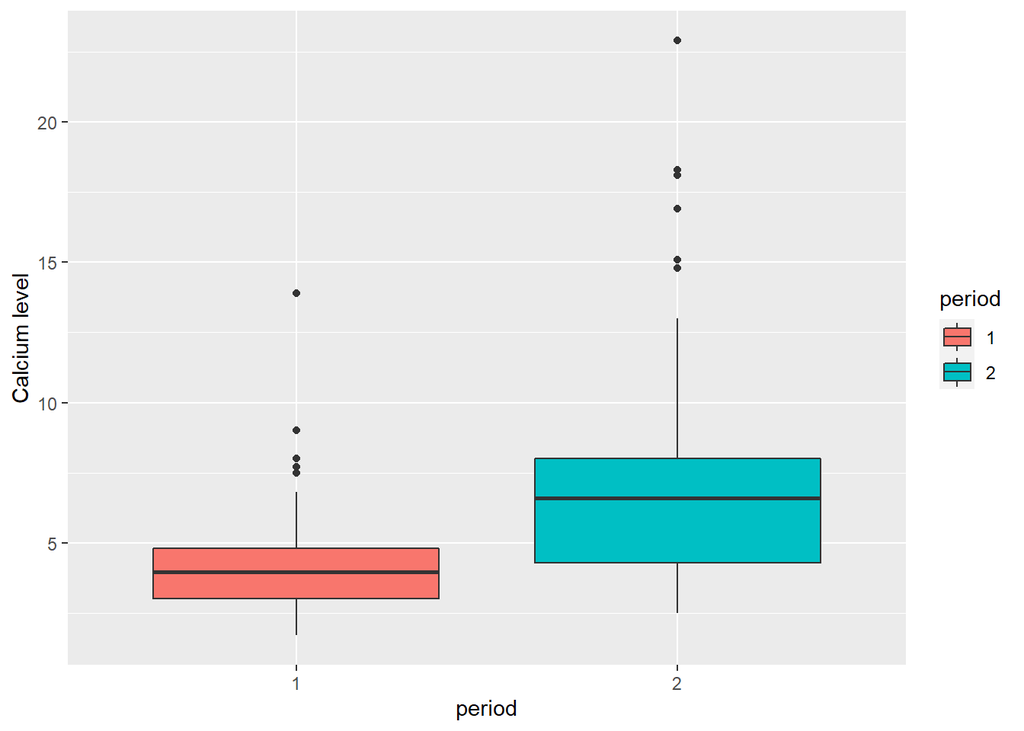

```r
male = ( MON810%>% filter(sex == "M"))
male$period = as.factor(male$period)
male %>%ggplot() + aes(x = period, y = CALCIUM) + geom_boxplot(aes(fill = period)) + ylab("Calcium level")
```

```r
male_period1 = ( MON810%>% filter(period == 1 & sex =="M")) $"CALCIUM"
male_period2 = ( MON810%>% filter(period == 2 & sex =="M")) $"CALCIUM"
wilcox.test(male_period1,male_period2,alternative = "two.sided")
```

```
##
##  Wilcoxon rank sum test with continuity correction
##
## data:  male_period1 and male_period2
## W = 2000.5, p-value = 2.838e-12
## alternative hypothesis: true location shift is not equal to 0
```

The p-value is $< 0.05$, so we can reject the hypothesis that the mean level of calcium is the same for the two populations.

3. test for the males if the mean level of calcium for period 2 is the same for the control group and the MON810 group.

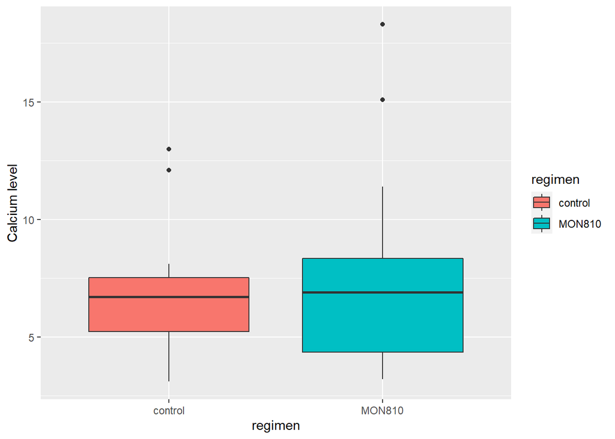

```r
regimen = MON810%>%filter((regimen=="control" | regimen=="MON810")&period=="2"&sex=="M")

regimen %>%ggplot() + aes(x = regimen, y = CALCIUM) + geom_boxplot(aes(fill = regimen)) + ylab("Calcium level")
```

```r
mon810 = ( MON810%>% filter(period == 2 & sex =="M" & regimen == "MON810"))$"CALCIUM"
control = ( MON810%>% filter(period == 2 & sex =="M" & regimen =="control" ))$"CALCIUM"

wilcox.test(control,mon810,alternative = "two.sided")
```

```
##
##  Wilcoxon rank sum test with continuity correction
##
## data:  control and mon810
## W = 175.5, p-value = 0.694
## alternative hypothesis: true location shift is not equal to 0
```

The p-value is greater than $0.05$. We accept the null hypothesis stating that for males the mean level of calcium for period 2 is the same for the control group and the MON810 group.

4. What is the probability to detect a difference of one standard deviation (1 sd) with only 10 animals per group? with 20 animal? How can we ensure to detect such difference with a probability of 80%?

```r
pwr.t.test(n = 10, d = 1, type = "two.sample",alternative="two.sided")
```

```
##
##      Two-sample t test power calculation
##
##               n = 10
##               d = 1
##       sig.level = 0.05
##           power = 0.5620066
##     alternative = two.sided
##
## NOTE: n is number in *each* group
```

For groups of 10 animals the probability to detect a difference of one standard deviation (1 sd) is $0.56$.

```r
pwr.t.test(n = 20, d = 1, type = "two.sample",alternative="two.sided")
```

```
##
##      Two-sample t test power calculation
##
##               n = 20
##               d = 1
##       sig.level = 0.05
##           power = 0.868953
##     alternative = two.sided
##
## NOTE: n is number in *each* group
```

For groups of 20 animals, the probability is equal to $0.86$.

```r
pwr.t.test(power = 0.8, d = 1)
```

```
##
##      Two-sample t test power calculation
##
##               n = 16.71472
##               d = 1
##       sig.level = 0.05
##           power = 0.8
##     alternative = two.sided
##
## NOTE: n is number in *each* group
```

## Multiple comparisons

1. Redo the three tests of the previous section (questions 1-3) for now comparing the means of all the quantitative variables. Store the results (the p-values) in a data frame with one variable per row and four columns (name of the variable + three p-values).

```r
do_all_comparisons <- function(data) {
  map(names (data)[5:51],
    function(g) {
      ### TEST1
    male_period2 <- filter(data, period == 2 & sex =="M" ) %>% pull(g)
    female_period2 <- filter(data, period == 2 & sex =="F" ) %>% pull(g)
    test1 <- t.test (male_period2,female_period2)

    male_period1 <- filter(data, period == 1 & sex =="M")%>% pull(g)
    test2 <- t.test (male_period1,male_period2)

    mon810 <- filter(data,period == 2 & sex =="M" & regimen == "MON810")%>% pull(g)
    control <- filter(data,period == 2 & sex =="M" & regimen == "control")%>% pull(g)
    test3 <- t.test (mon810,control)

    data.frame(
        regime    = g,
        p_val_test1 = test1$p.value,
        p_val_test2 = test2$p.value,
        p_val_test3 = test3$p.value
      ) %>% bind_rows()

  }) %>% bind_rows()
}
```

```r
all_comparisons <- do_all_comparisons(MON810)
all_comparisons %>% rmarkdown::paged_table(options = list(rows.print = 10))
```

| regime | p_val_test1 | p_val_test2 | p_val_test3 |
| --- | --- | --- | --- |
| ALBUMIN | 2.671973e-37 | 6.198082e-10 | 0.92670046 |
| ALKPHOSPH | 7.640668e-40 | 3.566211e-34 | 0.77971357 |
| SGPTALT | 3.934480e-03 | 7.441839e-02 | 0.84976243 |
| SGOTAST | 1.746933e-03 | 2.997316e-12 | 0.62083866 |
| BUN | 7.669199e-11 | 2.511871e-14 | 0.58396754 |
| CALCIUM blood | 1.167924e-05 | 2.168533e-52 | 0.89910519 |
| CREAT blood | 2.048889e-10 | 3.090504e-58 | 1.00000000 |
| Glycemia | 1.670859e-15 | 8.184426e-65 | 0.90483362 |
| PHOSPH blood | 3.393853e-03 | 9.496858e-37 | 0.39177006 |
| TOTPROT | 1.514556e-21 | 4.769457e-21 | 0.27831950 |

[output cut: 37 more lines]

2. For each of the three tests, adjust the p-values using the Bonferroni and the Benjamini-Hochberg corrections. How can we interpret these results?

```r
for (col in names (all_comparisons)[2:4]){
  all_comparisons[,paste("bonferroni",col)] <- p.adjust(all_comparisons %>% pull(col), method = "bonferroni")

  all_comparisons [,paste("BH",col)] <- p.adjust(all_comparisons%>% pull(col), method = "BH")
}

all_comparisons %>% rmarkdown::paged_table(options = list(rows.print = 10))
```

| regime | p_val_test1 | p_val_test2 | p_val_test3 | bonferroni p_val_test1 | BH p_val_test1 | bonferroni p_val_test2 | BH p_val_test2 | bonferroni p_val_test3 | BH p_val_test3 |
| --- | --- | --- | --- | --- | --- | --- | --- | --- | --- |
| ALBUMIN | 2.671973e-37 | 6.198082e-10 | 0.92670046 | 1.255827e-35 | 6.279136e-36 | 2.913098e-08 | 1.165239e-09 | 1 | 0.9468461 |
| ALKPHOSPH | 7.640668e-40 | 3.566211e-34 | 0.77971357 | 3.591114e-38 | 3.591114e-38 | 1.676119e-32 | 2.394456e-33 | 1 | 0.9468461 |
| SGPTALT | 3.934480e-03 | 7.441839e-02 | 0.84976243 | 1.849205e-01 | 5.603653e-03 | 1.000000e+00 | 8.744161e-02 | 1 | 0.9468461 |
| SGOTAST | 1.746933e-03 | 2.997316e-12 | 0.62083866 | 8.210586e-02 | 2.831236e-03 | 1.408739e-10 | 6.708279e-12 | 1 | 0.9468461 |
| BUN | 7.669199e-11 | 2.511871e-14 | 0.58396754 | 3.604523e-09 | 2.772710e-10 | 1.180579e-12 | 6.213576e-14 | 1 | 0.9468461 |
| CALCIUM blood | 1.167924e-05 | 2.168533e-52 | 0.89910519 | 5.489244e-04 | 2.195697e-05 | 1.019210e-50 | 3.397368e-51 | 1 | 0.9468461 |
| CREAT blood | 2.048889e-10 | 3.090504e-58 | 1.00000000 | 9.629780e-09 | 6.878414e-10 | 1.452537e-56 | 7.262685e-57 | 1 | 1.0000000 |
| Glycemia | 1.670859e-15 | 8.184426e-65 | 0.90483362 | 7.853039e-14 | 7.853039e-15 | 3.846680e-63 | 3.846680e-63 | 1 | 0.9468461 |
| PHOSPH blood | 3.393853e-03 | 9.496858e-37 | 0.39177006 | 1.595111e-01 | 5.105002e-03 | 4.463523e-35 | 8.927046e-36 | 1 | 0.9468461 |
| TOTPROT | 1.514556e-21 | 4.769457e-21 | 0.27831950 | 7.118413e-20 | 1.423683e-20 | 2.241645e-19 | 2.241645e-20 | 1 | 0.9468461 |

[output cut: 37 more lines]

Let’s see significant tests after both corrections.

```r
alpha <- 0.05

non_significant_test <- data.frame(

  Corrections = c("Bonferroni","BH"),

  Test1 = c(sum(all_comparisons$"bonferroni p_val_test1" < alpha),sum(all_comparisons$"BH p_val_test1" < alpha)),

  Test2 = c(sum(all_comparisons$"bonferroni p_val_test2" < alpha),sum(all_comparisons$"BH p_val_test2" < alpha)),

  Test3 = c(sum(all_comparisons$"bonferroni p_val_test3" < alpha),sum(all_comparisons$"BH p_val_test3" < alpha))

)




non_significant_test %>% rmarkdown::paged_table()
```

| Corrections | Test1 | Test2 | Test3 |
| --- | --- | --- | --- |
| Bonferroni | 28 | 33 | 0 |
| BH | 37 | 39 | 0 |

# Linear models: quarterly sales volumes

## Fitting a linear model

The file `sales1.csv` consists of quarterly sales volumes (in % and indexed to the time 0) of a product.

```r
sales1 <- readr::read_csv("data/sales1.csv", show_col_types = FALSE)
rmarkdown::paged_table(sales1)
```

| time | y |
| --- | --- |
| 1 | 101.82562 |
| 4 | 103.16069 |
| 7 | 99.48002 |
| 10 | 103.25016 |
| 13 | 106.46870 |
| 16 | 108.53795 |
| 19 | 104.75776 |
| 22 | 106.77594 |
| 25 | 109.89066 |
| 28 | 112.05444 |

[output cut: 11 more lines]

1. Plot the data and comment.

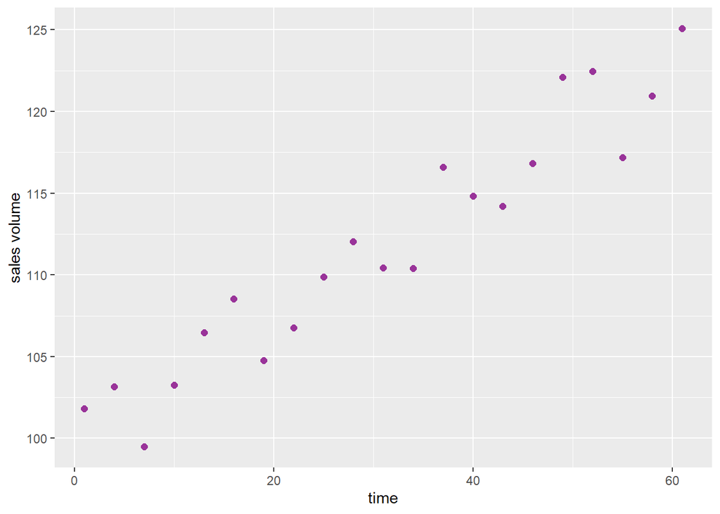

```r
sales_plot <- sales1 %>%
  ggplot() +  aes(x = time, y = y) +
  geom_point(size = 2, colour="#993399") +  xlab("time") + ylab("sales volume")
sales_plot
```

There is some periodic trend in the growth of the sales volume. In each period of 12 days, the sales increase to reach a local maximum then decreases until the tenth day.  
It is an additive time series with a periodic seasonality of 12 days.

2. Fit a polynomial model to this data (justify the choice of the degree). What do the residuals suggest?

```r
lm0 = lm(y~1,data=sales1)
lm1 = lm(y ~ poly(time, degree = 1), data = sales1)
lm2 = lm(y ~ poly(time, degree = 2), data = sales1)
lm3 = lm(y ~ poly(time, degree = 3), data = sales1)
lm4 = lm(y ~ poly(time, degree = 4), data = sales1)
```

```r
anova(lm0,lm1)
```

```
## Analysis of Variance Table
##
## Model 1: y ~ 1
## Model 2: y ~ poly(time, degree = 1)
##   Res.Df     RSS Df Sum of Sq      F    Pr(>F)
## 1     20 1091.90
## 2     19   91.99  1    999.91 206.53 1.166e-11 ***
## ---
## Signif. codes:  0 '***' 0.001 '**' 0.01 '*' 0.05 '.' 0.1 ' ' 1
```

The p-value of the Fisher test is $ 1.16*10^{-11} < 0.05 $ so lm1 is preferred to lm0.

```r
anova(lm1,lm2)
```

```
## Analysis of Variance Table
##
## Model 1: y ~ poly(time, degree = 1)
## Model 2: y ~ poly(time, degree = 2)
##   Res.Df    RSS Df Sum of Sq      F Pr(>F)
## 1     19 91.990
## 2     18 90.346  1    1.6437 0.3275 0.5742
```

```r
anova(lm2,lm3)
```

```
## Analysis of Variance Table
##
## Model 1: y ~ poly(time, degree = 2)
## Model 2: y ~ poly(time, degree = 3)
##   Res.Df    RSS Df Sum of Sq      F Pr(>F)
## 1     18 90.346
## 2     17 89.784  1   0.56202 0.1064 0.7482
```

```r
anova(lm1,lm3)
```

```
## Analysis of Variance Table
##
## Model 1: y ~ poly(time, degree = 1)
## Model 2: y ~ poly(time, degree = 3)
##   Res.Df    RSS Df Sum of Sq      F Pr(>F)
## 1     19 91.990
## 2     17 89.784  2    2.2057 0.2088 0.8136
```

Thanks to these anova tests, we conclude that the polynomial model with degree 1 is preferred. Let’s confirm this with another criterion.

```r
AIC(lm0,lm1,lm2,lm3,lm4)
```

```
##     df       AIC
## lm0  2 146.56961
## lm1  3  96.61563
## lm2  4  98.23700
## lm3  5 100.10596
## lm4  6 102.01336
```

```r
BIC(lm0,lm1,lm2,lm3,lm4)
```

```
##     df      BIC
## lm0  2 148.6587
## lm1  3  99.7492
## lm2  4 102.4151
## lm3  5 105.3286
## lm4  6 108.2805
```

Even with AIC and BIC criteria, lm1 is preferred as it has the lowest AIC and BIC.

3. Try to improve the model by adding a periodic component. Write your final model as a mathematical equation.

### Hints

- $$\cos(2\pi t/T)$$
  and
  $$\sin(2\pi t/T)$$
  are periodic functions of period $T$.
- One can easily deduce the period $T$ from the context and looking at the data.

From the data plot, we see that the period is almost 12. Let’s fit the data on this model
$$y = at +\alpha cos(\frac{2 \pi t}{T}) + \beta sin(\frac{2 \pi t}{T}) + b$$

```r
improved_lm <- lm(y ~ time + I(cos(2*time*pi/12)) + I(sin(2*time*pi/12)),data = sales1)
summary <- summary(improved_lm)
summary
```

```
##
## Call:
## lm(formula = y ~ time + I(cos(2 * time * pi/12)) + I(sin(2 *
##     time * pi/12)), data = sales1)
##
## Residuals:
##     Min      1Q  Median      3Q     Max
## -1.7557 -0.4608  0.1007  0.8127  1.2649
##
## Coefficients:
##                          Estimate Std. Error t value Pr(>|t|)
## (Intercept)              99.69815    0.44996 221.571  < 2e-16 ***
## time                      0.38611    0.01254  30.797 2.36e-16 ***
## I(cos(2 * time * pi/12))  1.18481    0.31757   3.731  0.00166 **
## I(sin(2 * time * pi/12))  2.35218    0.32593   7.217 1.44e-06 ***
## ---
## Signif. codes:  0 '***' 0.001 '**' 0.01 '*' 0.05 '.' 0.1 ' ' 1
##
## Residual standard error: 1.037 on 17 degrees of freedom
## Multiple R-squared:  0.9833, Adjusted R-squared:  0.9803
## F-statistic: 332.9 on 3 and 17 DF,  p-value: 2.716e-15
```

We see that the p-value for the student test for each coefficient is so small $<0.05$ which means that the null hypothesis $(coefficient =0)$ is rejected. All the the terms included in the model are important to explain the data.

4. Plot on a same graph the observed sales together with the predicted sales given by your final model. What do you think about this model? What about the residuals?

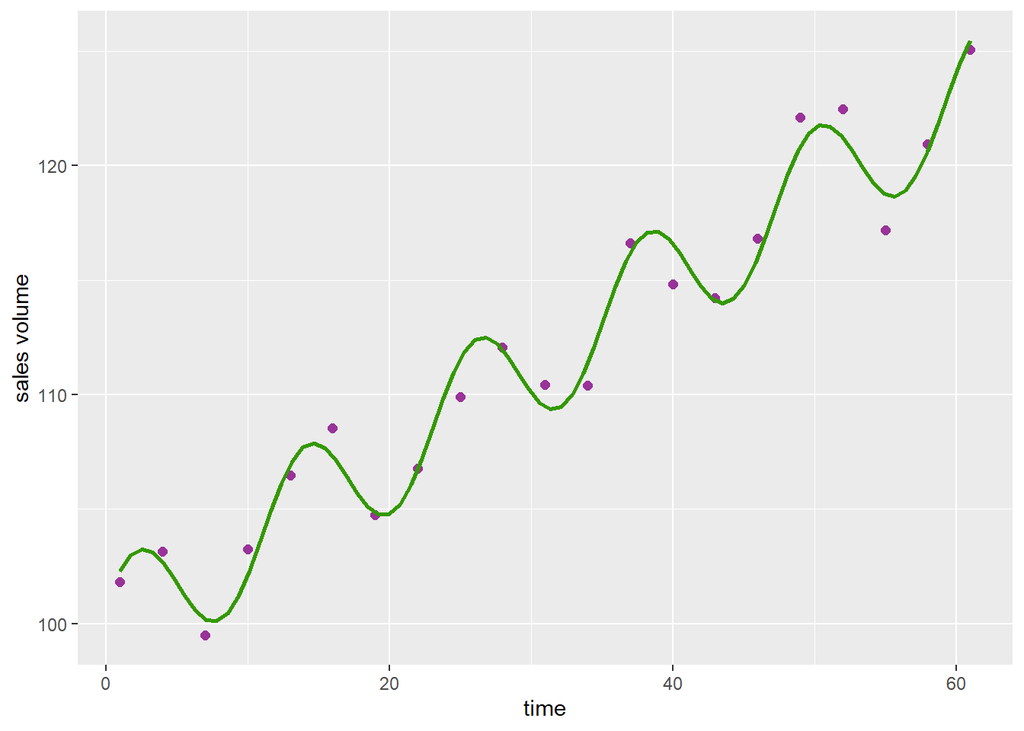

```r
sales_plot +   geom_smooth(method = "lm", formula = y ~ x + I(cos(2*x*pi/12)) + I(sin(2*x*pi/12)), se = FALSE, colour="#339900")
```

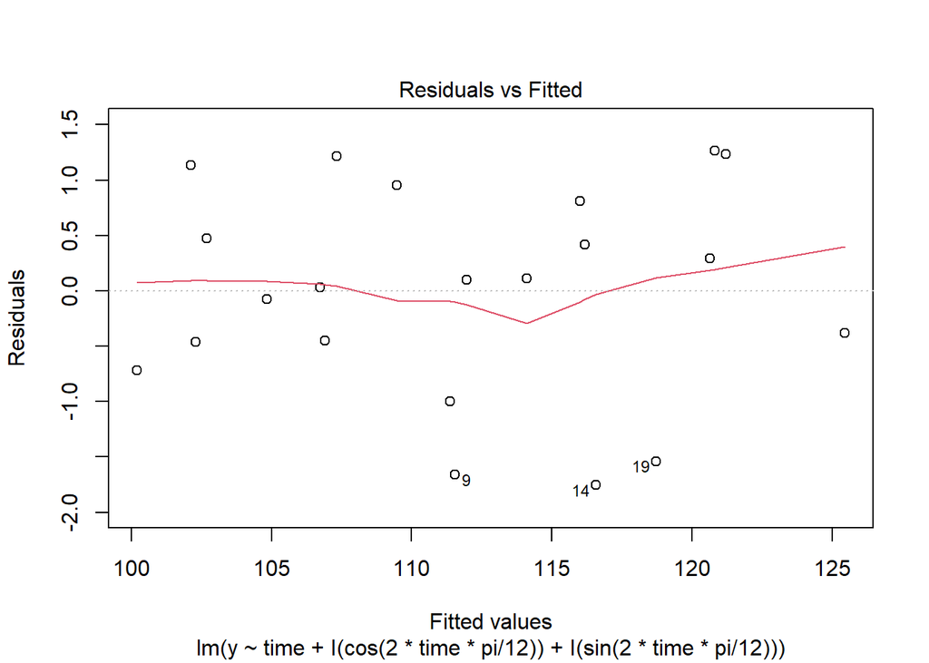

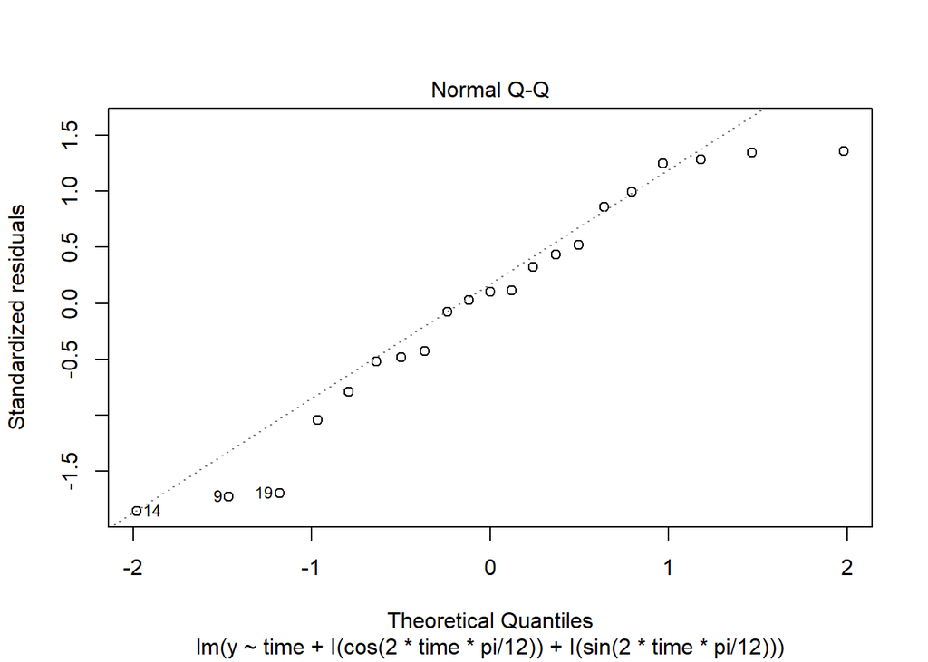

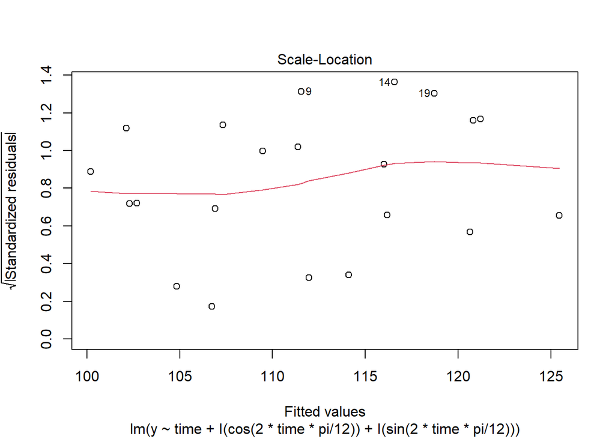

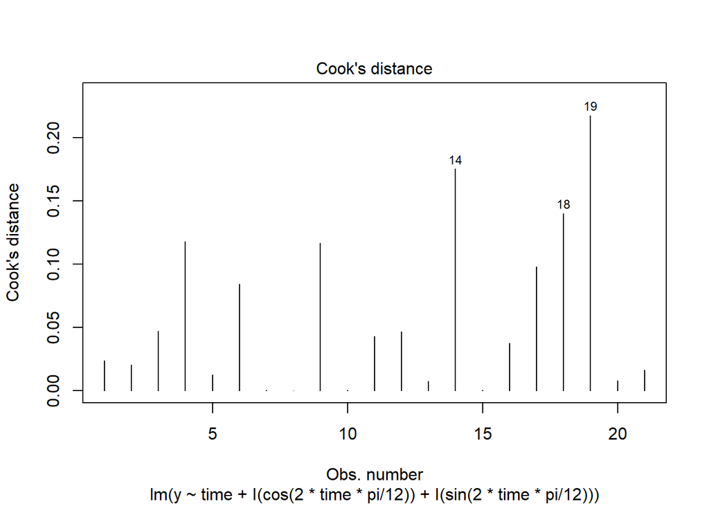

```r
plot (improved_lm,which = 1:4)
```

Thanks to the residuals plot we see that the residuals are centered around zero. Thanks to the normal QQ plot, the residuals satisfy the hypothesis of a normal distribution (but not perfectly). Thanks to scale location plot, the residuals satisfy the hypothesis of homoscedasticity.

```r
anova (lm1,improved_lm)
```

```
## Analysis of Variance Table
##
## Model 1: y ~ poly(time, degree = 1)
## Model 2: y ~ time + I(cos(2 * time * pi/12)) + I(sin(2 * time * pi/12))
##   Res.Df    RSS Df Sum of Sq      F    Pr(>F)
## 1     19 91.990
## 2     17 18.277  2    73.713 34.282 1.082e-06 ***
## ---
## Signif. codes:  0 '***' 0.001 '**' 0.01 '*' 0.05 '.' 0.1 ' ' 1
```

The p-value of the fisher test associated to the two nested models lm1 and improved_lm is $1.082 \times 10^{-6} < 0.05$ which means that the improved_lm is preferred to the normal linear model lm1.

5. We want the predicted sales volume to be equal to 100 at time 0. Modify your final model in order to take this constraint into account.

To satisfy this, the formula is
$$y = at +\alpha(cos(\frac{2 \pi t}{T}) -1 ) + \beta sin(\frac{2 \pi t}{T}) + 100$$

```r
improved_lm <- lm(y ~ 0 +  time + I(cos(2*time*pi/12) - 1) + I(sin(2*time*pi/12)) + offset(rep(100, length(time))),data = sales1)
summary <- summary(improved_lm)
summary
```

```
##
## Call:
## lm(formula = y ~ 0 + time + I(cos(2 * time * pi/12) - 1) + I(sin(2 *
##     time * pi/12)) + offset(rep(100, length(time))), data = sales1)
##
## Residuals:
##     Min      1Q  Median      3Q     Max
## -1.9858 -0.4548  0.2311  0.8582  1.7732
##
## Coefficients:
##                              Estimate Std. Error t value Pr(>|t|)
## time                         0.400663   0.008894  45.049  < 2e-16 ***
## I(cos(2 * time * pi/12) - 1) 0.888120   0.267237   3.323  0.00378 **
## I(sin(2 * time * pi/12))     2.408199   0.337386   7.138 1.19e-06 ***
## ---
## Signif. codes:  0 '***' 0.001 '**' 0.01 '*' 0.05 '.' 0.1 ' ' 1
##
## Residual standard error: 1.08 on 18 degrees of freedom
## Multiple R-squared:  0.9999, Adjusted R-squared:  0.9999
## F-statistic: 7.515e+04 on 3 and 18 DF,  p-value: < 2.2e-16
```

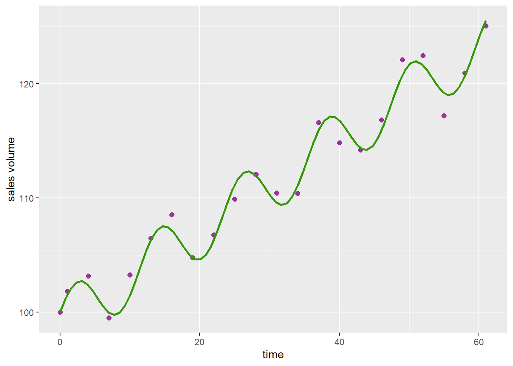

```r
## Add time =0 and y = 100
sales1[22,1] = 0
sales1[22,]$y = 100


## Plot the new model
sales_plot <- sales1 %>%
  ggplot() +  aes(x = time, y = y) +
  geom_point(size = 2, colour="#993399") +  xlab("time") + ylab("sales volume")


sales_plot +   geom_smooth(method = "lm", formula = y ~ 0 +  x + I(cos(2*x*pi/12) - 1) + I(sin(2*x*pi/12)) + offset(rep(100, length(x))), se = FALSE, colour="#339900")
```

With the new model, the initial condition is satisfied.

## Fitting a linear mixed effects model

The file `sales30.csv` now consists of quarterly sales volumes (still in % and indexed to the time 0) of 30 different products.

```r
sales30 <- readr::read_csv("data/sales30.csv", show_col_types = FALSE) %>% mutate(id = as.factor(id))
rmarkdown::paged_table(sales30)
```

| id | time | y |
| --- | --- | --- |
| 1 | 1 | 101.82562 |
| 1 | 4 | 103.16069 |
| 1 | 7 | 99.48002 |
| 1 | 10 | 103.25016 |
| 1 | 13 | 106.46870 |
| 1 | 16 | 108.53795 |
| 1 | 19 | 104.75776 |
| 1 | 22 | 106.77594 |
| 1 | 25 | 109.89066 |
| 1 | 28 | 112.05444 |

[output cut: 620 more lines]

1. Plot the data and comment

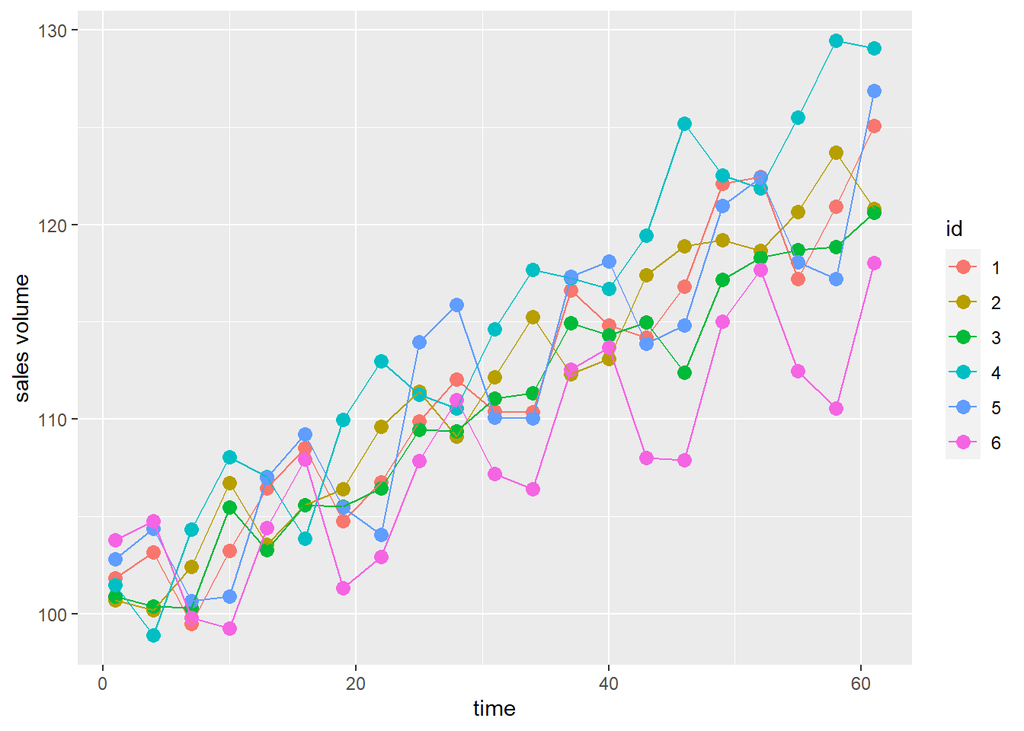

```r
sales_plot2 <- sales30[1:126,] %>%
  ggplot() +  aes(x = time, y = y, color = id)  +  geom_point(size = 3) + xlab("time") + ylab("sales volume")
sales_plot2  + geom_line()
```

We see on this plot, that even if the sales seem to increase linearly (with a periodic component) for each individual, the intercept and the slope may change from a subject to another one.

2. Adjust the model used previously for fitting the first series to this data and comment the results.

```r
classical_model <- lm(y ~ time + I(cos(2*time*pi/12)) + I(sin(2*time*pi/12)),data = sales30)
summary <- summary(classical_model)
summary
```

```
##
## Call:
## lm(formula = y ~ time + I(cos(2 * time * pi/12)) + I(sin(2 *
##     time * pi/12)), data = sales30)
##
## Residuals:
##      Min       1Q   Median       3Q      Max
## -19.7030  -2.9607   0.1117   3.3645  17.4116
##
## Coefficients:
##                           Estimate Std. Error t value Pr(>|t|)
## (Intercept)              100.09336    0.42471 235.676  < 2e-16 ***
## time                       0.21655    0.01183  18.299  < 2e-16 ***
## I(cos(2 * time * pi/12))   0.89834    0.29975   2.997  0.00283 **
## I(sin(2 * time * pi/12))   1.24348    0.30764   4.042 5.96e-05 ***
## ---
## Signif. codes:  0 '***' 0.001 '**' 0.01 '*' 0.05 '.' 0.1 ' ' 1
##
## Residual standard error: 5.36 on 626 degrees of freedom
## Multiple R-squared:  0.3634, Adjusted R-squared:  0.3603
## F-statistic: 119.1 on 3 and 626 DF,  p-value: < 2.2e-16
```

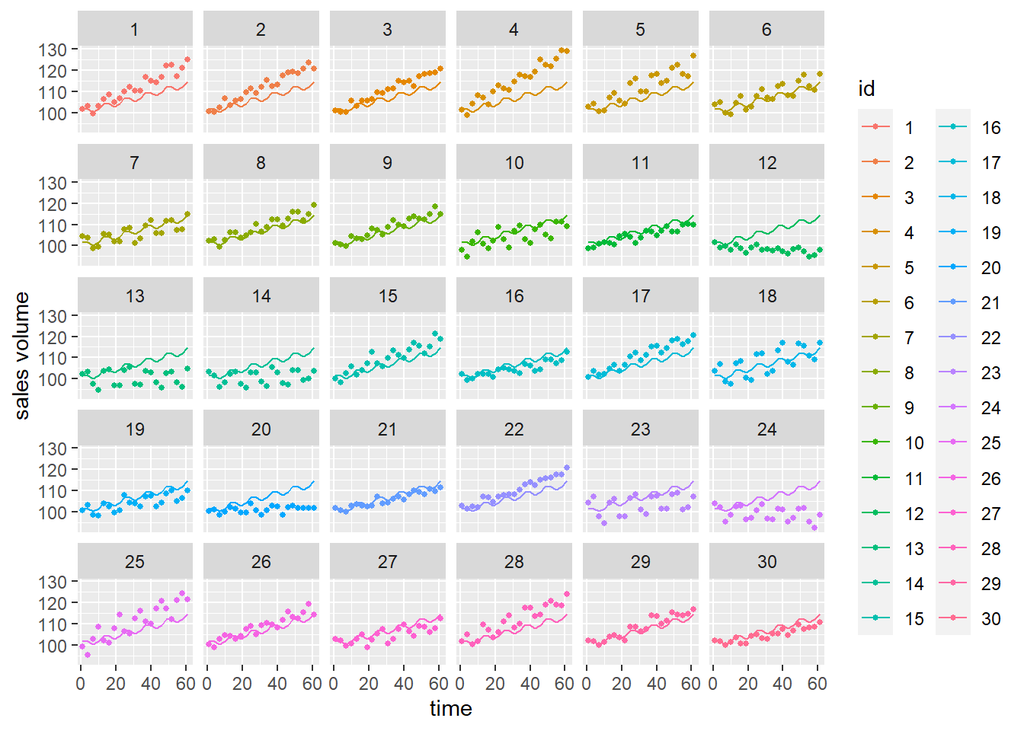

```r
sales30 %>%
  ggplot() +  aes(x = time, y = y, color = id)  +  geom_point(size = 1) + xlab("time") + ylab("sales volume") + geom_line(aes(x = time, y = predict(classical_model), color = id))  + facet_wrap(~id)
```

3. Fit a mixed effect model to this data (discuss the choice of fixed and random effects). Write your final model as a mathematical equation.

We’ll try different combinations of mixed effects model.

```r
lmem1 <- lmer(y ~ 1 + time + I(cos(2*time*pi/12)) + I(sin(2*time*pi/12)) + (1 + time|id) ,data = sales30)
summary(lmem1)
```

```
## Linear mixed model fit by REML ['lmerMod']
## Formula: y ~ 1 + time + I(cos(2 * time * pi/12)) + I(sin(2 * time * pi/12)) +
##     (1 + time | id)
##    Data: sales30
##
## REML criterion at convergence: 2975.3
##
## Scaled residuals:
##      Min       1Q   Median       3Q      Max
## -3.01855 -0.62510 -0.04121  0.69157  3.09091
##
## Random effects:
##  Groups   Name        Variance Std.Dev. Corr
##  id       (Intercept) 0.001161 0.03407
##           time        0.018889 0.13744  -0.72
##  Residual             5.229117 2.28673
## Number of obs: 630, groups:  id, 30
##
## Fixed effects:
##                           Estimate Std. Error t value
## (Intercept)              100.09336    0.18128 552.133
## time                       0.21655    0.02559   8.460
## I(cos(2 * time * pi/12))   0.89834    0.12787   7.025
## I(sin(2 * time * pi/12))   1.24348    0.13124   9.475
##
## Correlation of Fixed Effects:
##                (Intr) time   I(c(2*t*p/12))
## time           -0.194
## I(c(2*t*p/12))  0.023 -0.012
## I(s(2*t*p/12)) -0.102  0.020 -0.045
## optimizer (nloptwrap) convergence code: 0 (OK)
## Model failed to converge with max|grad| = 0.159943 (tol = 0.002, component 1)
```

```r
lmem2 <- lmer(y ~ 1 + time + I(cos(2*time*pi/12))  + I(sin(2*time*pi/ 12)) +(1 + time + I(cos(2*time*pi/12))|id) ,data = sales30)
```

```
## boundary (singular) fit: see ?isSingular
```

```r
summary(lmem2)
```

```
## Linear mixed model fit by REML ['lmerMod']
## Formula: y ~ 1 + time + I(cos(2 * time * pi/12)) + I(sin(2 * time * pi/12)) +
##     (1 + time + I(cos(2 * time * pi/12)) | id)
##    Data: sales30
##
## REML criterion at convergence: 2975
##
## Scaled residuals:
##      Min       1Q   Median       3Q      Max
## -3.02609 -0.62175 -0.04258  0.68974  3.10606
##
## Random effects:
##  Groups   Name                     Variance Std.Dev. Corr
##  id       (Intercept)              0.001543 0.03928
##           time                     0.018993 0.13781  -1.00
##           I(cos(2 * time * pi/12)) 0.003304 0.05748   1.00 -1.00
##  Residual                          5.227641 2.28640
## Number of obs: 630, groups:  id, 30
##
## Fixed effects:
##                           Estimate Std. Error t value
## (Intercept)              100.09336    0.18129 552.104
## time                       0.21655    0.02566   8.438
## I(cos(2 * time * pi/12))   0.89834    0.12828   7.003
## I(sin(2 * time * pi/12))   1.24348    0.13122   9.476
##
## Correlation of Fixed Effects:
##                (Intr) time   I(c(2*t*p/12))
## time           -0.209
## I(c(2*t*p/12))  0.026 -0.092
## I(s(2*t*p/12)) -0.102  0.020 -0.045
## optimizer (nloptwrap) convergence code: 0 (OK)
## boundary (singular) fit: see ?isSingular
```

```r
lmem3 <- lmer(y ~ 1 + time + I(cos(2*time*pi/12))  + I(sin(2*time*pi/ 12))+ (1 + time + I(sin(2*time*pi/12))|id) ,data = sales30)
summary(lmem3)
```

```
## Linear mixed model fit by REML ['lmerMod']
## Formula: y ~ 1 + time + I(cos(2 * time * pi/12)) + I(sin(2 * time * pi/12)) +
##     (1 + time + I(sin(2 * time * pi/12)) | id)
##    Data: sales30
##
## REML criterion at convergence: 2131.8
##
## Scaled residuals:
##      Min       1Q   Median       3Q      Max
## -3.05574 -0.60247  0.01991  0.62114  3.11302
##
## Random effects:
##  Groups   Name                     Variance Std.Dev. Corr
##  id       (Intercept)              0.01878  0.137
##           time                     0.01821  0.135     0.62
##           I(sin(2 * time * pi/12)) 8.39427  2.897     0.54 -0.32
##  Residual                          1.03090  1.015
## Number of obs: 630, groups:  id, 30
##
## Fixed effects:
##                           Estimate Std. Error  t value
## (Intercept)              100.09336    0.08425 1188.105
## time                       0.21655    0.02474    8.752
## I(cos(2 * time * pi/12))   0.89834    0.05678   15.823
## I(sin(2 * time * pi/12))   1.24348    0.53217    2.337
##
## Correlation of Fixed Effects:
##                (Intr) time   I(c(2*t*p/12))
## time            0.110
## I(c(2*t*p/12))  0.022 -0.005
## I(s(2*t*p/12))  0.150 -0.314 -0.005
```

```r
lmem4 <- lmer(y ~ 1 + time + I(cos(2*time*pi/12))  + I(sin(2*time*pi/ 12))+ (1 + time + I(sin(2*time*pi/12)) + I(cos(2*time*pi/12))|id)  ,data = sales30)
```

```
## boundary (singular) fit: see ?isSingular
```

```r
summary(lmem4)
```

```
## Linear mixed model fit by REML ['lmerMod']
## Formula: y ~ 1 + time + I(cos(2 * time * pi/12)) + I(sin(2 * time * pi/12)) +
##     (1 + time + I(sin(2 * time * pi/12)) + I(cos(2 * time * pi/12)) |
##         id)
##    Data: sales30
##
## REML criterion at convergence: 2126
##
## Scaled residuals:
##      Min       1Q   Median       3Q      Max
## -3.03998 -0.61045  0.03931  0.63481  3.03666
##
## Random effects:
##  Groups   Name                     Variance Std.Dev. Corr
##  id       (Intercept)              0.01773  0.1332
##           time                     0.01822  0.1350    0.64
##           I(sin(2 * time * pi/12)) 8.42919  2.9033    0.53 -0.32
##           I(cos(2 * time * pi/12)) 0.01937  0.1392   -0.84 -0.13 -0.90
##  Residual                          1.02034  1.0101
## Number of obs: 630, groups:  id, 30
##
## Fixed effects:
##                           Estimate Std. Error  t value
## (Intercept)              100.09336    0.08364 1196.668
## time                       0.21655    0.02475    8.750
## I(cos(2 * time * pi/12))   0.89834    0.06194   14.504
## I(sin(2 * time * pi/12))   1.24348    0.53323    2.332
##
## Correlation of Fixed Effects:
##                (Intr) time   I(c(2*t*p/12))
## time            0.110
## I(c(2*t*p/12)) -0.081 -0.056
## I(s(2*t*p/12))  0.142 -0.311 -0.372
## optimizer (nloptwrap) convergence code: 0 (OK)
## boundary (singular) fit: see ?isSingular
```

Let’s compare the four models :

```r
BIC(lmem1,lmem2,lmem3,lmem4)
```

```
##       df      BIC
## lmem1  8 3026.819
## lmem2 11 3045.944
## lmem3 11 2202.684
## lmem4 15 2222.694
```

```r
AIC(lmem1,lmem2,lmem3,lmem4)
```

```
##       df      AIC
## lmem1  8 2991.253
## lmem2 11 2997.041
## lmem3 11 2153.781
## lmem4 15 2156.008
```

4. Plot the data with the predicted sales given by the chosen model.

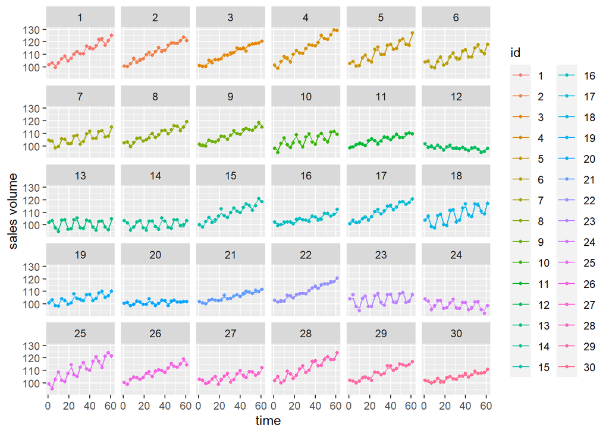

```r
 sales30 %>%
  ggplot() +  aes(x = time, y = y, color = id) +
  geom_point(size = 1) +  xlab("time") + ylab("sales volume") + geom_line(aes(x = time, y = predict(lmem3), color = id)) + facet_wrap(~id)
```

After zooming on the plots, we see that our model fits better each id individually.